# XOR with h2o

Mladen Kolar (mkolar@chicagobooth.edu)

# Input variable transformation

The purpose of this example is to provide a simple illustration on what the neural network learns.

We will be using the neural network implementation in the `h2o` package.

```r
library(h2o)
```

The following command will start a server. `h20` is written in Java programming language and we are only using the R interface.

The parameter `nthreads=1` controls how many threads you are going to use for the server. If you set `nthreads=-1` then all the compute power would be allocated to the server.

```r
h2oServer <- h2o.init(nthreads=1)
```

[output not shown]

```r
h2o.no_progress()      # prevents progress bar from showing
```

We will generate a synthetic dataset with the XOR pattern.

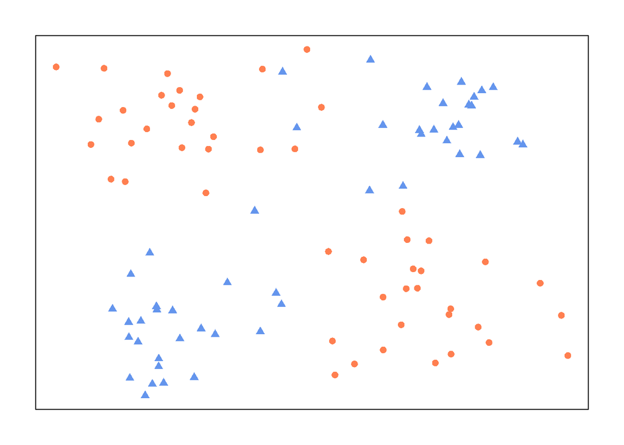

```r
set.seed(1)

p11 = cbind(rnorm(n=25,mean=1,sd=0.5),rnorm(n=25,mean=1,sd=0.5))
p12 = cbind(rnorm(n=25,mean=-1,sd=0.5),rnorm(n=25,mean=1,sd=0.5))
p13 = cbind(rnorm(n=25,mean=-1,sd=0.5),rnorm(n=25,mean=-1,sd=0.5))
p14 = cbind(rnorm(n=25,mean=1,sd=0.5),rnorm(n=25,mean=-1,sd=0.5))

g = as.factor(c(rep(0,50),rep(1,50)))
x = rbind(p11,p13,p12,p14)

# plot points
par(mar=rep(2,4))
plot(x,
     col=ifelse(g==1, "coral", "cornflowerblue"),
     pch=ifelse(g==1, 16,17),
     axes=FALSE)
box()
```

We need to load data into `h2o` as follows. We use `as.h2o(...)`.

```r
dfh2o = as.h2o(data.frame(x=x,y=g), destination_frame = "xor.train")
```

Next, we prepare the grid of points for testing

```r
px1 = seq(min(x[,1]), max(x[,1]), length.out = 100)
px2 = seq(min(x[,2]), max(x[,2]), length.out = 100)
gd = expand.grid(x.1=px1, x.2=px2)
```

and load it into `h2o`

```r
dftest = as.h2o(gd, destination_frame = "xor.test")
```

We are ready to train our first neural network with 1 hidden layer containing 2 neurons.

```r
#  1 hidden 2 neurons
model = h2o.deeplearning(x=1:2, y=3,
                         training_frame = dfh2o,
                         hidden = 2,
                         activation = "Tanh",
                         epochs = 1000,
                         export_weights_and_biases = TRUE,
                         model_id = "xor.model.h1n2",
                         seed = 2
)
```

Using the model, we make a prediction on the grid.

```r
phat = h2o.predict(model, dftest)
```

The third column of the `phat` object correspond to the probability of class 1.

```r
phat = matrix( phat[,3], length(px1), length(px2) )
```

We visualize the decision boundary.

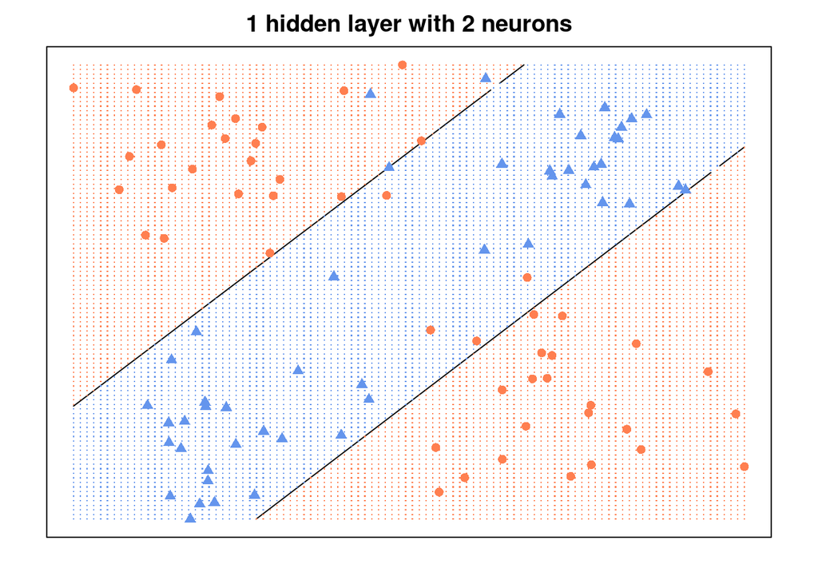

```r
par(mar=rep(2,4))
contour(px1, px2, phat, levels=0.5, labels="", xlab="", ylab="",
        main= "1 hidden layer with 2 neurons",
        axes=FALSE)
points(gd, pch=".", cex=1.2,
       col=ifelse(phat>0.5, "coral", "cornflowerblue"))
points(x,
       col=ifelse(g==1, "coral", "cornflowerblue"),
       pch=ifelse(g==1, 16,17))
box()
```

What did the neurons learn? We can extract weights and biases for the hidden neurons.

```r
h2o.biases(model, vector_id = 1)
```

```
##          C1
## 1 -0.667946
## 2 -1.405283
##
## [2 rows x 1 column]
```

```r
h2o.weights(model, matrix_id = 1)
```

```
##        x.1      x.2
## 1  1.11610 -1.10658
## 2 -2.13354  2.12627
##
## [2 rows x 2 columns]
```

Let us compute the output of the first layer when we use the following points as input.

| x1 | x2 | y |
| --- | --- | --- |
| -1 | -1 | + |
| -1 | 1 | - |
| 1 | -1 | - |
| 1 | 1 | + |

```r
tmp.df = as.h2o(
  data.frame(x.1=c(-1, -1, 1, 1), x.2=c(-1, 1, -1, 1)),
  destination_frame = "xor.4points")
trans.features = h2o.deepfeatures(model, tmp.df, layer = 1)
as.matrix( h2o.cbind(tmp.df, trans.features) )
```

```
##      x.1 x.2  DF.L1.C1  DF.L1.C2
## [1,]  -1  -1 -0.664423 -0.821292
## [2,]  -1   1 -0.991510  0.987741
## [3,]   1  -1  0.835313 -0.999908
## [4,]   1   1 -0.618614 -0.859309
```

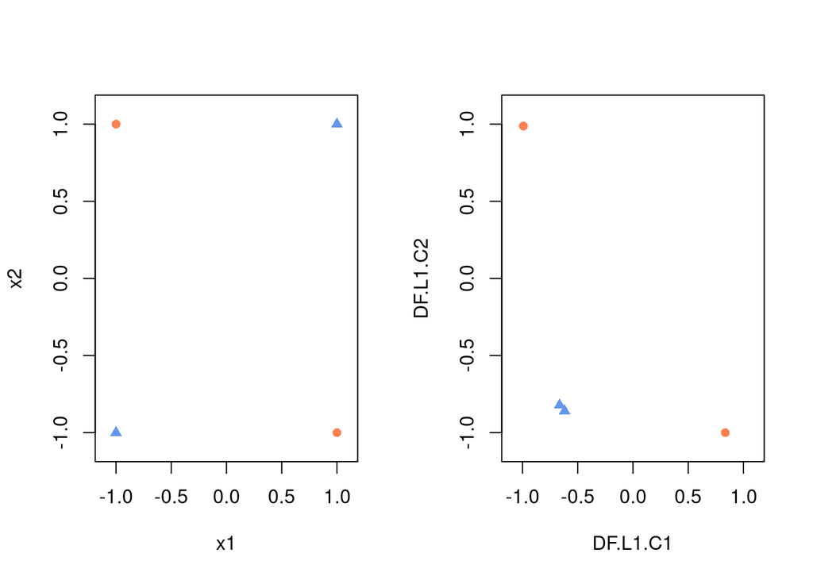

```r
par(mfrow=c(1,2))
plot(c(-1, -1, 1, 1),
     c(-1, 1, -1, 1),
     xlim=c(-1.1,1.1), ylim=c(-1.1,1.1),
     col = c("cornflowerblue","coral","coral","cornflowerblue"),
     pch = c(17,16,16,17),
     type="p",
     xlab="x1", ylab="x2")
plot(as.matrix(trans.features)[,1],
     as.matrix(trans.features)[,2],
     xlim=c(-1.1,1.1), ylim=c(-1.1,1.1),
     col = c("cornflowerblue","coral","coral","cornflowerblue"),
     pch = c(17,16,16,17),
     type="p",
     xlab="DF.L1.C1", ylab="DF.L1.C2")
```

Let us now transform all of the original data.

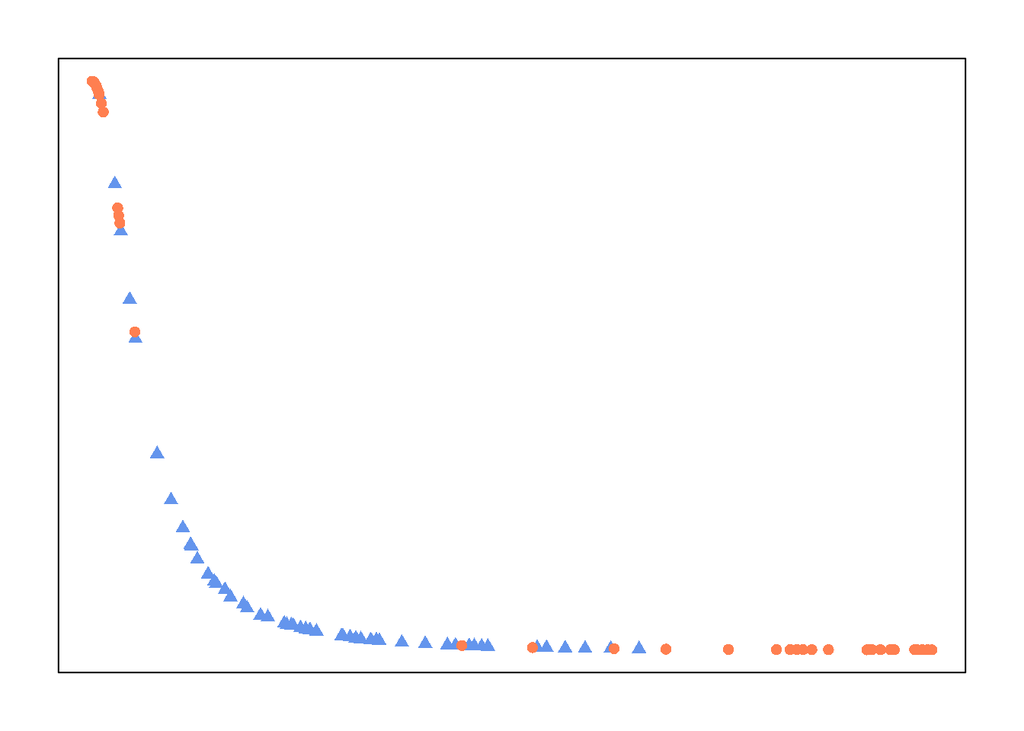

```r
trans.features = h2o.deepfeatures(model, dfh2o[,1:2], layer = 1)
par(mar=rep(2,4))
plot(jitter(as.matrix(trans.features)),
     col=ifelse(g==1, "coral", "cornflowerblue"),
     pch=ifelse(g==1, 16,17),
     axes=FALSE)
box()
```

We observe that the neural network has learned how to transform the observations, so that they are linearly separable in the new space.

# Complexity of the fit

Let us now train neural networks with more hidden neurons.

**1 hidden 5 neurons**

```r
model5 = h2o.deeplearning(x=1:2, y=3,
                          dfh2o,
                          hidden = c(5),
                          activation = "Tanh",
                          epochs = 5000,
                          export_weights_and_biases = TRUE,
                          model_id = "xor.model.h1n5",
                          seed = 1
)
```

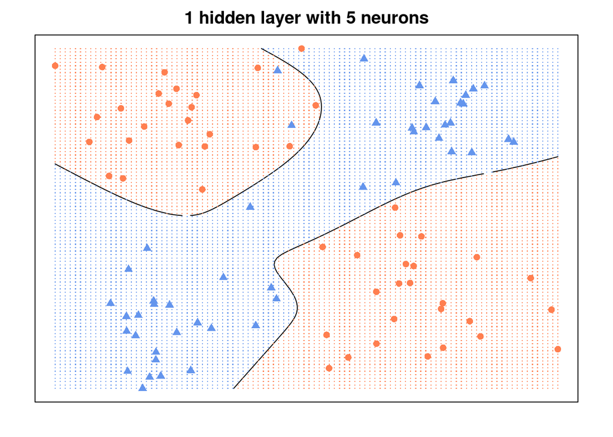

```r
phat = h2o.predict(model5, dftest)
phat = matrix( phat[,3], length(px1), length(px2) )

par(mar=rep(2,4))
contour(px1, px2, phat, levels=0.5, labels="", xlab="", ylab="",
        main= "1 hidden layer with 5 neurons",
        axes=FALSE)
points(gd, pch=".", cex=1.2,
       col=ifelse(phat>0.5, "coral", "cornflowerblue"))
points(x,
       col=ifelse(g==1, "coral", "cornflowerblue"),
       pch=ifelse(g==1, 16,17))
box()
```

**1 hidden 10 neurons**

```r
model10 = h2o.deeplearning(x=1:2, y=3,
                           dfh2o,
                           hidden = c(10),
                           activation = "Tanh",
                           epochs = 5000,
                           export_weights_and_biases = TRUE,
                           model_id = "xor.model.h1n10"
)
```

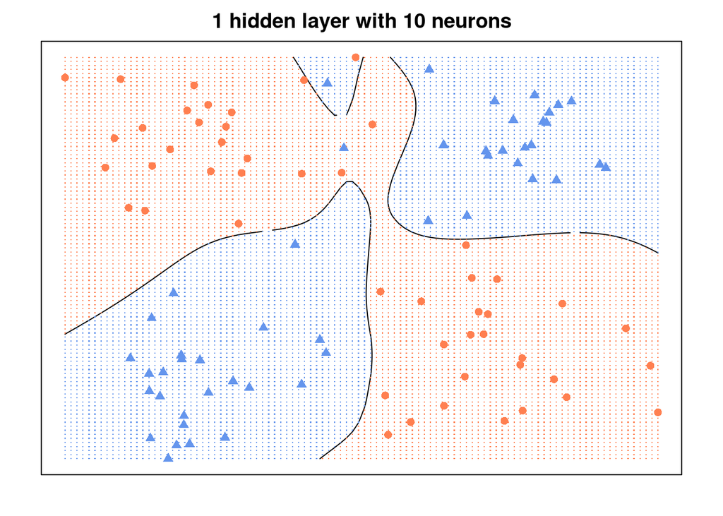

```r
phat = h2o.predict(model10, dftest)
phat = matrix( phat[,3], length(px1), length(px2) )

par(mar=rep(2,4))
contour(px1, px2, phat, levels=0.5, labels="", xlab="", ylab="",
        main= "1 hidden layer with 10 neurons",
        axes=FALSE)
points(gd, pch=".", cex=1.2,
       col=ifelse(phat>0.5, "coral", "cornflowerblue"))
points(x,
       col=ifelse(g==1, "coral", "cornflowerblue"),
       pch=ifelse(g==1, 16,17))
box()
```

We observe that the number of neurons in the hiden layer controls the complexity of the fitted function.

- it is very easy to over-fit.

We can use regularization to prevent over-fitting.

**1 hidden 10 neurons regularized**

```r
model10.reg = h2o.deeplearning(x=1:2, y=3,
                               dfh2o,
                               hidden = c(10),
                               activation = "Tanh",
                               epochs = 5000,
                               export_weights_and_biases = TRUE,
                               l1 = 2e-2,
                               model_id = "xor.model.h1n10.reg",
                               seed = 1
)
```

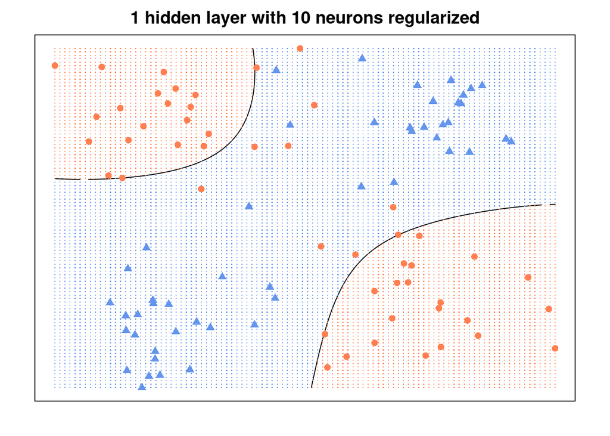

```r
phat = h2o.predict(model10.reg, dftest)
phat = matrix( phat[,3], length(px1), length(px2) )

par(mar=rep(2,4))
contour(px1, px2, phat, levels=0.5, labels="", xlab="", ylab="",
        main= "1 hidden layer with 10 neurons regularized",
        axes=FALSE)
points(gd, pch=".", cex=1.2,
       col=ifelse(phat>0.5, "coral", "cornflowerblue"))
points(x,
       col=ifelse(g==1, "coral", "cornflowerblue"),
       pch=ifelse(g==1, 16,17))
box()
```